# The Top 0.4% of Finland: an Analysis of Incomes and Tax Rates from 2009 to 2013

Kyle Ott and Cornelius Schneider

December 4, 2014

# Introduction (1)

In a very recent work, Piketty and Saez (2014) identify additional reasons why trends in top-income shares are correlated with the tax rates:

- labor responses
- evasion/avoidance responses
- and bargaining responses.

The current debate still lacks information about the top of the income distribution.

Our paper’s purpose is to identify anomalies in the tax patterns of ultra-wealthy Finnish people.

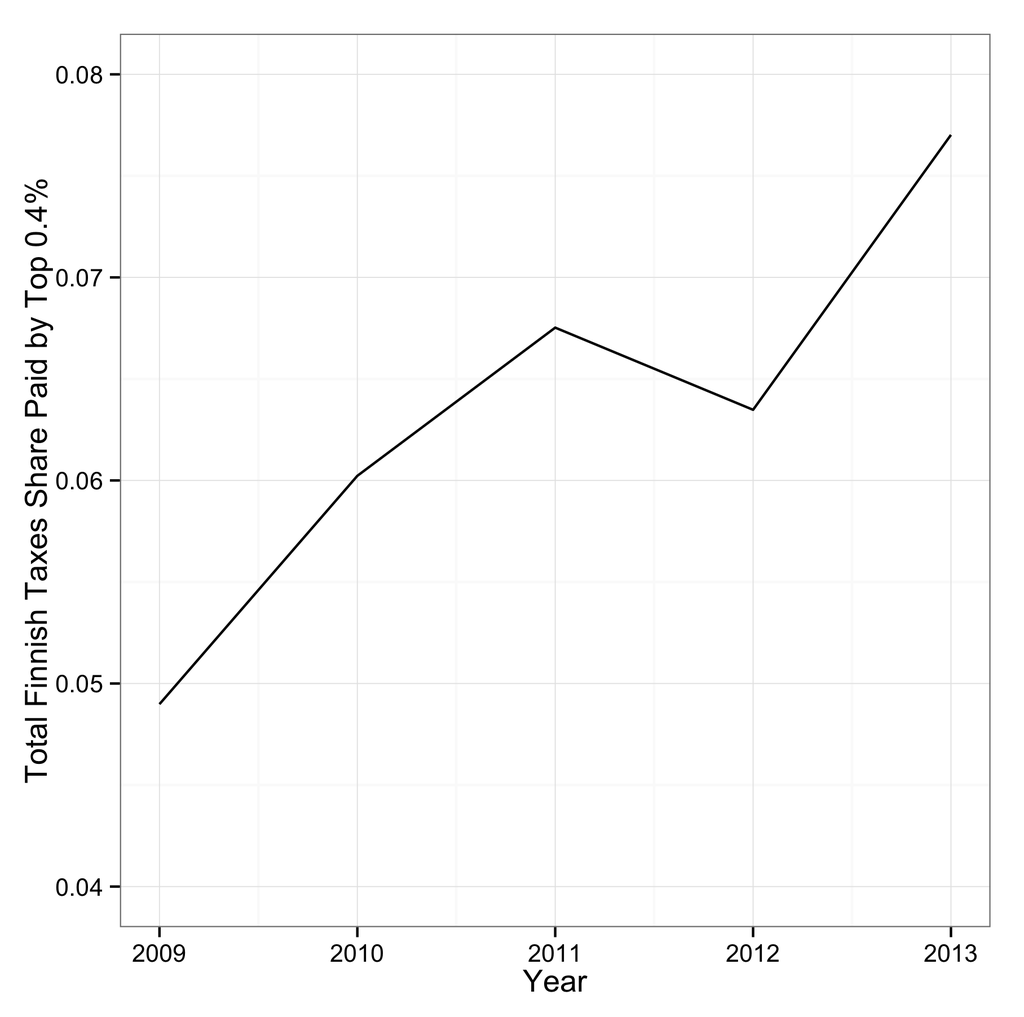

# Introduction (3): Why Finland?

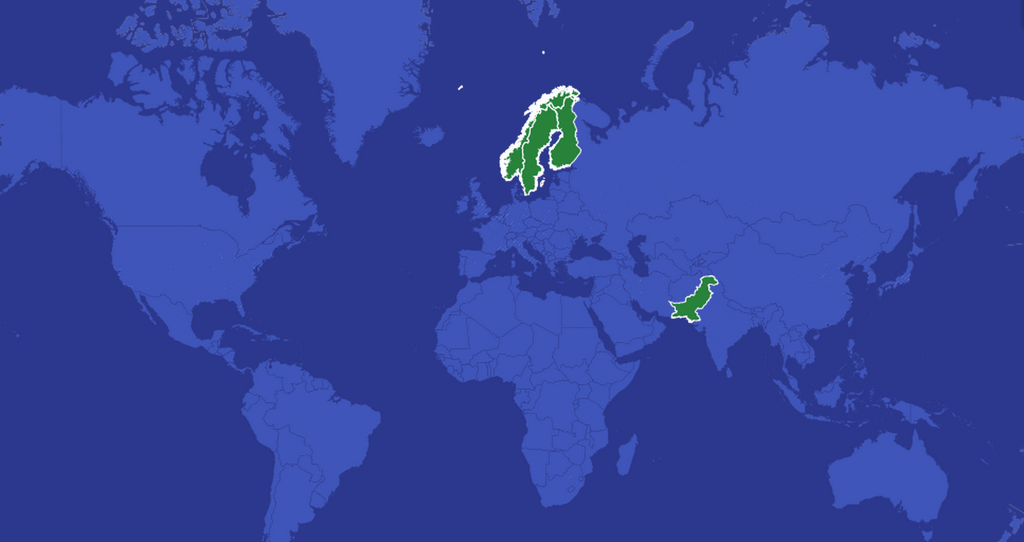

# Our data (1)

[figure not shown]

Taloussanomat

# Our data (2)

- 70,402 observations (N = ~15,000 ; T = 5)
- Scraped all five years: 2009 to 2013
- Created time series dataset
- Created panel dataset using names as unique id’s (N = 4867)
- Variables
  - Name
  - Total Income
  - Total Taxes Paid
  - Average Tax Rate
  - Rank